# Diagonal Case - Multiple Stocks/Ages

## 3.3 The output from the fit

Here is the fitted spline curve to the number of unmarked fish available in each recovery sample

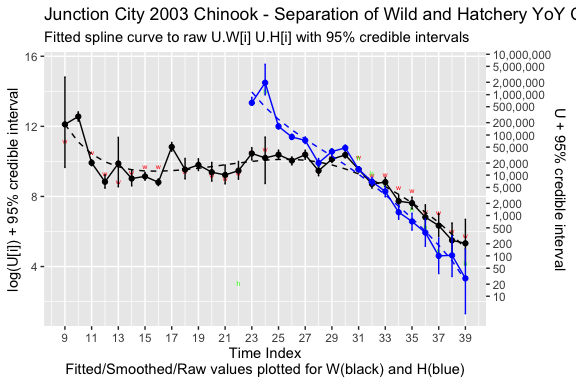

Fitted spline curve

```r
demo.fit$plots$fit.plot
```

The separation of wild and hatchery fish is evident as well has the start of the spline for the hatchery fish.

A plot of the $logit(P)$ is

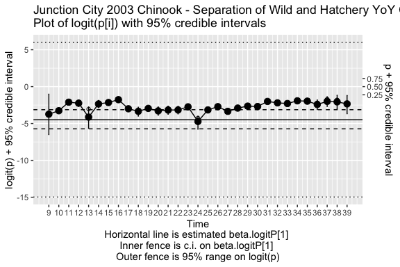

Estimates of logit(p)

```r
demo.fit$plots$logitP.plot
```

In cases where there is no information (such as the first julian week), $BTSPAS$ has interpolated based on the distribution of catchability in the other strata and so the credible interval is very wide.

A summary of the posterior for each parameter is also available. In particular, here are the summary statistics on the posterior sample for the total number unmarked separated by wild and hatchery origin:

```r
demo.fit$summary[ row.names(demo.fit$summary) %in% c("Ntot","Utot","Utot.H","Utot.W"),]
```

```
#>           mean      sd      2.5%     25%       50%     75%   97.5%      Rhat n.eff
#> Utot   4886878 2201403 2876388.7 3190186 3550698.7 7225287 8138957  3.741584     3
#> Utot.H 3672542 2007050 2006948.2 2205647 2392307.5 6300015 6924714 17.726043     3
#> Utot.W 1214336 1199008  722701.6  825935  926705.4 1169012 3487257  1.072534    50
```

# 4 Wild and Hatchery Chinook with YoY and Age 1 fish.

In this example, *BTSPAS* allows for separating wild from hatchery Chinook salmon when Age-1 Chinook Salmon are present (residualized) from last year.

In each stratum $j$, $n1[j]$ fish are marked and released above a rotary screw trap. Of these, $m2[j]$ are recaptured in the stratum of release, i.e. the matrix of releases and recoveries is diagonal. The $n1[j]$ and $m2[j]$ establish the capture efficiency of the trap.

At the same time, $u2[j]$ unmarked fish are captured at the screw trap. These fish are a mixture of YoY and Age-1 wild and hatchery raised Chinook Salmon. A portion (*clip.rate.H.YoY*, *clip.rate.H.1*) of the YoY and Age1 hatchery raised fish are adipose fin clipped and can be recognized as hatchery raised. The unclipped fish are a mixture of wild and hatchery fish which must be separated. Hence the $u2[j]$ are separated into

- $u2.A.YoY[j]$ representing the number of YoY adipose clipped fish known to be hatchery fish, and
- $u2.N.YoY[j]$ representing the number YoY unclipped fish which are mixture of hatchery and wild fish
- $u2.A.1 [j]$ representing the number of Age1 adipose clipped fish known to be hatchery fish, and
- $u2.N.1 [j]$ representing the number of Age1 unclipped fish) which are mixture of hatchery and wild fish.

## 4.1 Reading in the data

Here is an example of some raw data that is read in:

```r
demo2.data.csv <- textConnection(
"     jweek,      n1,      m2,      u2.A.YoY,      u2.N.YoY,      u2.A.1,      u2.N.1
          2,       0,       0,             0,            15,           0,          10
          3,       0,       0,             0,            94,           1,          90
          4,     833,      52,             0,           385,           2,         112
          5,     852,      67,             0,          1162,          12,         140
          6,    1495,      77,             0,           592,          10,         103
          7,    1356,     182,             0,          1151,           4,          94
          8,    1889,     145,             0,          2258,           7,         121
          9,    2934,      89,             0,          1123,           2,          80
         10,    1546,      53,             0,          2277,           5,          57
         11,    4001,     232,             0,          2492,           4,          27
         12,    2955,     158,             0,          1579,          14,          88
         13,     529,      14,             0,          1046,           5,          45
         14,    1172,      49,             0,           766,           3,          13
         15,    3204,     232,             0,          2702,           1,           9
         16,    1328,      57,             0,         10408,           2,          18
         17,    3540,     114,             0,         12145,           3,          15
         18,    4791,      45,             0,           186,           0,           1
         19,    4808,      11,             0,           407,           0,           2
         20,    5952,      44,             0,           862,           0,           0
         21,    3852,      55,             0,           465,           0,           0
         22,    2621,      17,             0,           724,           0,          27
         23,    2131,      37,           854,          4860,           0,           0
         24,    5002,     152,           794,          3539,           0,           1
         25,    3706,     120,           904,          4597,           0,           0
         26,    1225,      44,           708,          3819,           0,           0
         27,     723,      45,           762,          3300,           0,           0
         28,    2895,     167,          1356,          5460,           0,           0
         29,    1395,     117,           614,          2918,           0,           0
         30,     479,      77,           420,          2252,           0,           0
         31,     964,      74,           289,          1240,           0,           0
         32,    2803,     288,            87,           428,           0,           0
         33,     952,      51,           114,           464,           0,           0
         34,     880,     126,            53,           515,           0,           0
         35,       0,       0,            21,            93,           0,           0")

demo2.data <- read.csv(demo2.data.csv, header=TRUE, as.is=TRUE, strip.white=TRUE)

print(demo2.data)
```

```
#>    jweek   n1  m2 u2.A.YoY u2.N.YoY u2.A.1 u2.N.1
#> 1      2    0   0        0       15      0     10
#> 2      3    0   0        0       94      1     90
#> 3      4  833  52        0      385      2    112
#> 4      5  852  67        0     1162     12    140
#> 5      6 1495  77        0      592     10    103
#> 6      7 1356 182        0     1151      4     94
#> 7      8 1889 145        0     2258      7    121
#> 8      9 2934  89        0     1123      2     80
#> 9     10 1546  53        0     2277      5     57
#> 10    11 4001 232        0     2492      4     27
#> 11    12 2955 158        0     1579     14     88
#> 12    13  529  14        0     1046      5     45
#> 13    14 1172  49        0      766      3     13
#> 14    15 3204 232        0     2702      1      9
```

[output cut: 20 more lines]

There are several unusual features of the data set:

- No fish were tagged and released in the first two strata nor in the last stratum. So no information is available to estimate the capture efficiency at the second trap in these strata.
- There one julian week where the number of unmarked fish captured suddenly jumps by several orders of magnitude. This jump correspond to releases of hatchery fish into the system.
- Before the hatchery release, we know that all of the unmarked fish without an adipose clip are wild fish.